# Modelamiento macroecológico

Julián Velasco

10/6/2021

En esta sección haremos un ejercicio de modelación de riqueza de especies o modelo macroecológico (MEM en breve) en función de un conjunto de variables bioclimáticas y evaluaremos la capacidad predictiva del modelo con datos por fuera de la muestra y haremos algunas proyecciones a futuro usando escenarios de cambio climático.

Descargue los datos de aquí: https://www.dropbox.com/sh/9ks083qx3f0jm5m/AADOj-uvf3tUEGtHaBQ_1Kosa?dl=0

```r
# instalar y cargar todos estos paquetes

library(raster)
```

```r
library(sp)
library(maptools)
library(rgdal)
library(dismo)
library(XML)
library(maps)
library(letsR)
library(plyr)
library(groupdata2)
library(rgeos)
library(classInt)
library(Metrics)
library(RColorBrewer)
library(rcompanion)
library(plotKML)
library(lmtest)
library(spdep)
library(lme4)
library(reshape2)
library(usdm)
```

Cargar shapefile con areas de distribución (extent of occurrence EOO) de todas las especies de ranas de la familia Centrolenidae (ranas de cristal).

```r
crs.geo <- CRS("+proj=longlat +ellps=WGS84 +datum=WGS84")  # geographical, datum WGS84

mapas <-readOGR("./Shapefiles/Centrolenidae_IUCN.shp")
projection(mapas)<-crs.geo
```

Generar un mapa de riqueza y una matriz de presencia-ausencia (PAM) usando los mapas individuales.

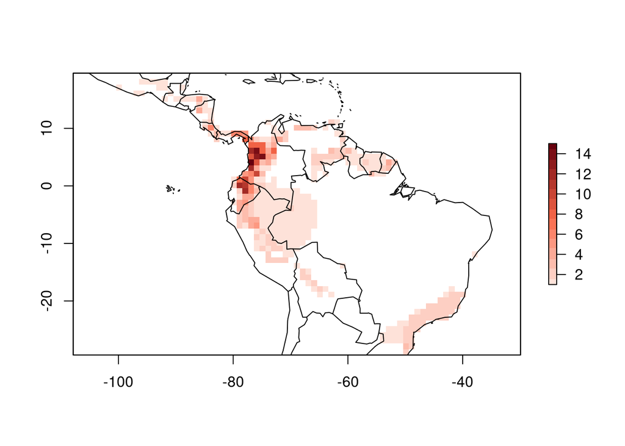

```r
PAM_centro <-lets.presab(mapas, xmn=-100.4, xmx=-37.5, ymn=-29.3, ymx=19.6, resol=1,
                         remove.cells=TRUE, remove.sp=TRUE, show.matrix=FALSE,
                         crs=CRS("+proj=longlat +ellps=WGS84 +datum=WGS84"), cover=0, presence=NULL,
                         origin=NULL, seasonal=NULL, count=FALSE)
#
plot(PAM_centro)
```

```r
#
PAM_centro
```

```
##
## Class: PresenceAbsence
## Number of species: 148
## Number of cells: 359
## Resolution: 1, 1 (x, y)
```

```r
#
str(PAM_centro)
```

[output not shown]

Extraer raster

```r
rr <- PAM_centro$Richness_Raster
```

Cargar un mapa de países (shapefile)

```r
am <-readOGR("./Shapefiles/america_completo.shp")
projection(am)<-crs.geo
```

Graficar

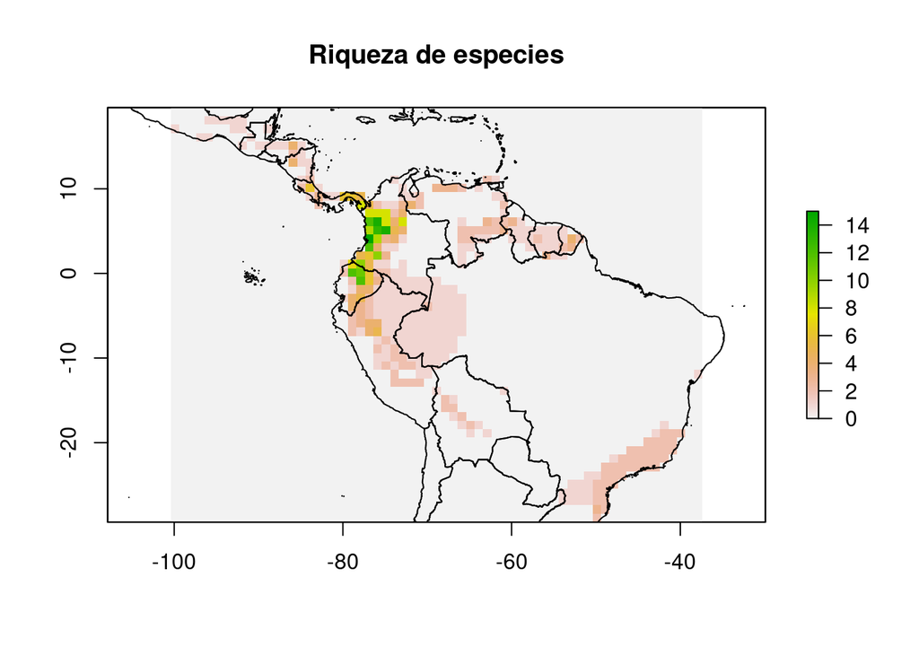

```r
plot(rr, main="Riqueza de especies")
plot(am, add=T)
```

Subir capas bioclimáticas actuales y futuras

```r
bios.act <- stack(list.files(path="./Bioclimaticos/actual/", pattern = "tif", full.names = T))
bios.fut <- stack(list.files(path="./Bioclimaticos/rcp85_2070/bc85bi70/", pattern = "tif", full.names = T))

projection(bios.act)<-crs.geo
projection(bios.fut)<-crs.geo
```

Extraer datos de variables ambientales para cada celda con datos de riqueza

```r
PAM_centro_bios <- lets.addvar(PAM_centro, bios.act, fun=mean,  onlyvar = TRUE)
PAM_centro_biosF <- lets.addvar(PAM_centro, bios.fut, fun=mean,  onlyvar = TRUE)
```

Preparar los conjuntos de datos de riqueza de especies y variables bioclimáticas

```r
PAM_DF <- as.data.frame(PAM_centro$Presence_and_Absence_Matrix)
a <- rowSums(PAM_DF[,c(-1:-2)])
DF_SR <- PAM_DF[,c(1:2)]
DF_SR["Riqueza"] <- a

DF_SR_Bios <- round(cbind(DF_SR, PAM_centro_bios),1)
DF_SR_BiosFut <- round(cbind(DF_SR, PAM_centro_biosF),1)
```

Construir el modelo de regresión. Esta parte es muy importante porque es necesario tener una buena calibración y que el modelo tenga buena capacidad de predicción de la riqueza por fuera de la muestra. Primero vamos a generar una partición aleatoria de los datos. Hay otro tipo de particiones estructuradas que se pueden usar (e.g., stratified, block, checkerboard, véase el siguiente enlace: http://cran.nexr.com/web/packages/ENMeval/vignettes/ENMeval-vignette.html#partition).

```r
partitions <- partition(DF_SR_Bios, p=0.7)
train <- partitions[[1]]
test <- partitions[[2]]
trainDF <- as.data.frame(train)
testDF <- as.data.frame(test)
```

Ajustar el modelo. Usaremos una regresión lineal con el método de mínimos cuadrados ordinarios (OLS en inglés). Este método hace una estimación de los parámetros minimizando la suma de residuales al cuadrado. Es el método más sencillo.

```r
m.ols <- lm(Riqueza~., data=trainDF[,c(-1,-2)])
summary(m.ols)
```

```
##
## Call:
## lm(formula = Riqueza ~ ., data = trainDF[, c(-1, -2)])
##
## Residuals:
##     Min      1Q  Median      3Q     Max
## -4.5131 -0.6452 -0.1201  0.5616  7.6380
##
## Coefficients:
##               Estimate Std. Error t value Pr(>|t|)
## (Intercept) -2.146e+01  9.054e+00  -2.370 0.018603 *
## bio_01_mean -1.191e-01  1.778e-01  -0.669 0.503856
## bio_02_mean -4.004e-01  1.147e-01  -3.490 0.000578 ***
## bio_03_mean  4.317e-01  1.223e-01   3.531 0.000500 ***
## bio_04_mean -7.763e-03  6.928e-03  -1.121 0.263658
## bio_05_mean -8.151e-02  2.120e+00  -0.038 0.969370
## bio_06_mean  1.657e-01  2.121e+00   0.078 0.937800
## bio_07_mean  4.236e-01  2.128e+00   0.199 0.842363
## bio_08_mean  6.739e-02  5.030e-02   1.340 0.181638
## bio_09_mean  8.482e-02  5.057e-02   1.677 0.094833 .
## bio_10_mean  8.689e-02  2.375e-01   0.366 0.714814
## bio_11_mean -2.408e-01  3.112e-01  -0.774 0.439923
## bio_12_mean  7.634e-04  1.511e-03   0.505 0.613949
## bio_13_mean  2.801e-02  9.650e-03   2.903 0.004058 **
## bio_14_mean -1.063e-02  2.533e-02  -0.420 0.675080
## bio_15_mean  2.930e-02  1.700e-02   1.723 0.086168 .
## bio_16_mean -1.690e-02  3.993e-03  -4.231 3.35e-05 ***
## bio_17_mean -2.981e-03  9.387e-03  -0.318 0.751124
## bio_18_mean  9.194e-03  1.806e-03   5.092 7.37e-07 ***
## bio_19_mean  4.489e-03  1.219e-03   3.682 0.000288 ***
## ---
## Signif. codes:  0 '***' 0.001 '**' 0.01 '*' 0.05 '.' 0.1 ' ' 1
##
## Residual standard error: 1.537 on 231 degrees of freedom
## Multiple R-squared:  0.4986, Adjusted R-squared:  0.4574
## F-statistic: 12.09 on 19 and 231 DF,  p-value: < 2.2e-16
```

Generamos la predicción usando el conjunto de datos que se dejaron por fuera (fuera de la muestra).

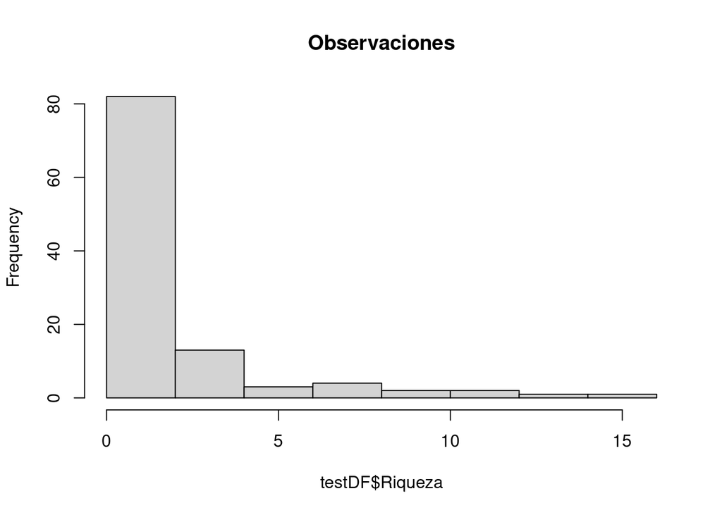

```r
pred.ols <- predict(m.ols, testDF)

# Comparación entre observaciones y predicciones.
par(mfrow=c(1,1))
hist(testDF$Riqueza, main="Observaciones")
```

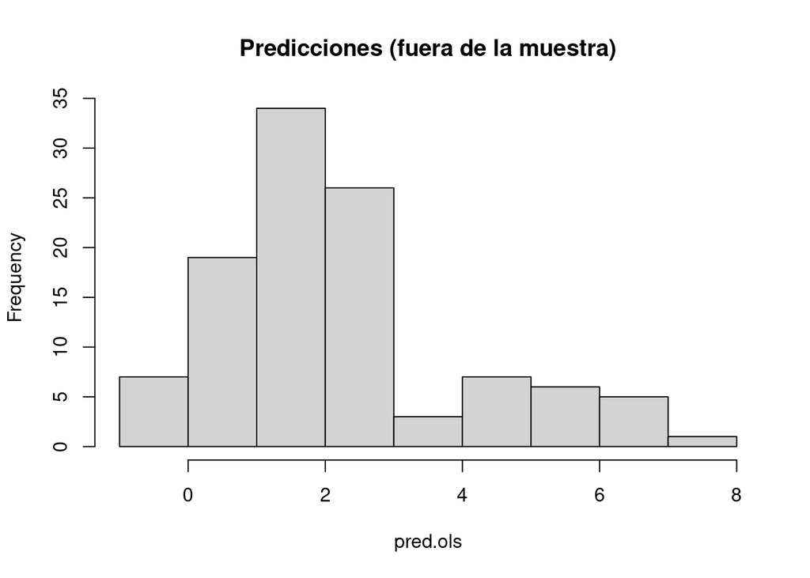

```r
hist(pred.ols, main="Predicciones (fuera de la muestra)")
```

Ahora vamos a hacer un “loop” para generar 100 particiones aleatorias de los datos y hacer una validación cruzada.

```r
nsim <- 100
mfit_ols <- list() # guarda cada modelo ajustado
rsq_ols <- list() # guarda cada R2 calculado
rmse_ols <- list() # guarda la raíz del error cuadrático medio RMSE
pred_ols <- list() # valores predichos fuera de la muestra

for (i in 1:nsim){
#
partitions <- partition(DF_SR_Bios, p=0.7)
train <- partitions[[1]]
test <- partitions[[2]]
trainDF <- as.data.frame(train)
testDF <- as.data.frame(test)

# model fit
m.ols <- lm(Riqueza~., data=trainDF[,c(-1:-2)])
mfit_ols[[i]] <- m.ols

# predictions
pred.ols <- predict(m.ols, testDF[,c(-1:-2)])
pred_ols[[i]] <- pred.ols

# metrics
rss <- sum((pred.ols - testDF$Riqueza) ^ 2)  ## suma de cuadrados residuales
tss <- sum((testDF$Riqueza - mean(testDF$Riqueza)) ^ 2)  ## suma total de cuadrados
rsq_ols[[i]] <- 1 - rss/tss # R2
rmse_ols[[i]] <- rmse(testDF$Riqueza, pred.ols) #  raíz del error cuadrático medio RMSE
}
```

Hacemos un histograma de los 100 valores de R2 y RMSE

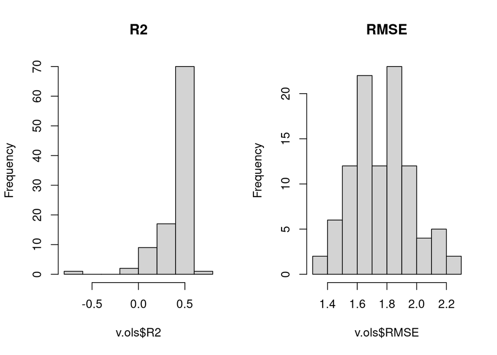

```r
bb <- cbind(as.numeric(rsq_ols), as.numeric(rmse_ols))
colnames(bb) <- c("R2", "RMSE")
v.ols <- as.data.frame(bb)

par(mfrow=c(1,2))
hist(v.ols$R2, main="R2")
hist(v.ols$RMSE, main="RMSE")
```

Ahora vamos a ajustar un modelo linear generalizado. Es más flexible que el OLS y permite acomodar mejorar la variación de los datos porque la variable de respuesta puede tener un tipo de distribución diferente a la Gaussiana (no normal).

```r
# GLM
nsim <- 100
# to run models across a sample of 100 spatial folds
mfit_glm <- list() # model fitted
rsq_glm <- list() # R squared
rmse_glm <- list() # Root Mean Squared Error
pred_glm <- list() # predicciones fuera de la muestra

for (i in 1:nsim){
#
partitions <- partition(DF_SR_Bios, p=0.7)
train <- partitions[[1]]
test <- partitions[[2]]
trainDF <- as.data.frame(train)
testDF <- as.data.frame(test)

# model fit
m.glm <- glm(Riqueza~., data = trainDF[,c(-1:-2)], family=poisson())
mfit_glm[[i]] <- m.glm

# predictions
pred.glm <- predict(m.glm, newdata=testDF[,c(-1:-2)], type="response", se.fit=FALSE)
pred_glm[[i]] <- pred.glm

# metrics
rss <- sum((pred.glm - testDF$Riqueza) ^ 2)  ## suma de cuadrados residuales
tss <- sum((testDF$Riqueza - mean(testDF$Riqueza)) ^ 2)  ## suma total de cuadrados
rsq_glm[[i]] <- 1 - rss/tss # R2
rmse_glm[[i]] <- rmse(testDF$Riqueza, pred.glm) #  raíz del error cuadrático medio RMSE
}
```

Hacemos el histograma de los 100 valores de R2 y RMSE y comparamos el GLM con el OLS

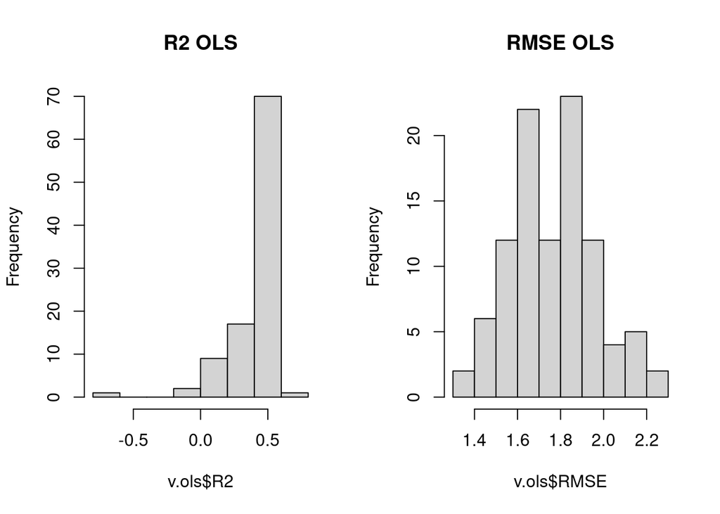

```r
bb <- cbind(as.numeric(rsq_glm), as.numeric(rmse_glm))
colnames(bb) <- c("R2", "RMSE")
v.glm <- as.data.frame(bb)


par(mfrow=c(1,2))
hist(v.ols$R2, main="R2 OLS")
hist(v.ols$RMSE, main="RMSE OLS")
```

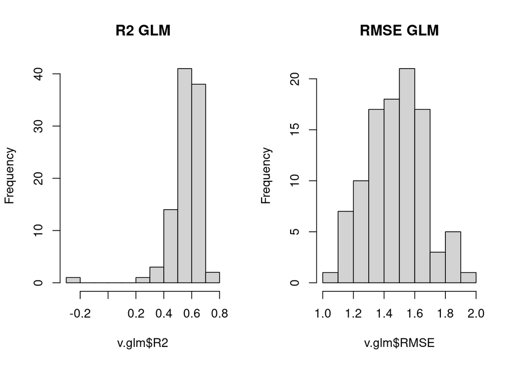

```r
par(mfrow=c(1,2))
hist(v.glm$R2, main="R2 GLM")
hist(v.glm$RMSE, main="RMSE GLM")
```

Vamos a generar unos escenarios futuros de riqueza de especies. Recuerde las diferencias entre pronóstico, predicción y proyección. Cuando hablamos de cambio climático el término adecuado es proyección o escenario futuro.

```r
#  Proyectar a futuro
options(scipen=999) # quitamos la notación científica


m.ols <- lm(Riqueza~., data=DF_SR_Bios[,c(-1:-2)])
m.glm <- glm(Riqueza~., data=DF_SR_Bios[,c(-1:-2)], family=poisson())

pred.ols.act <- round(predict(m.ols, newdata=DF_SR_Bios[,c(-1:-2)], type="response", se.fit=FALSE),1)
pred.glm.act <- round(predict(m.glm, newdata=DF_SR_Bios[,c(-1:-2)], type="response", se.fit=FALSE),1)

pred.ols.fut <- round(predict(m.ols, newdata=DF_SR_BiosFut[,c(-1:-2)], type="response", se.fit=FALSE),1)
pred.glm.fut <- round(predict(m.glm, newdata=DF_SR_BiosFut[,c(-1:-2)], type="response", se.fit=FALSE),1)
```

Comparamos las ganancias y pérdidas potenciales de especies a futuro usando el modelo OLS y el GLM

```r
pp.ols <- pred.ols.fut - pred.ols.act # negativo = pérdidas, positivo = ganancias
pp.glm <- pred.glm.fut - pred.glm.act # negativo = pérdidas, positivo = ganancias
```

Hacemos un dataframe con las predicciones futuras

```r
DF_SR_Bios["pred_ols_act"] <- pred.ols.act
DF_SR_Bios["pred_ols_fut"] <- pred.ols.fut

DF_SR_Bios["pred_glm_act"] <- pred.glm.act
DF_SR_Bios["pred_glm_fut"] <- pred.glm.fut
```

Convertimos las predicción en formato aster

```r
DF_SR_Bios_sp <- DF_SR_Bios
DF_SR_Bios_sp <- plyr::rename(DF_SR_Bios_sp, replace=c("Longitude(x)"="x", "Latitude(y)"="y"))
coordinates(DF_SR_Bios_sp)<- ~ x + y

class(DF_SR_Bios_sp)
```

```
## [1] "SpatialPointsDataFrame"
## attr(,"package")
## [1] "sp"
```

```r
obs.r <- vect2rast(DF_SR_Bios_sp, fname = "Riqueza", cell.size=1)
obs.r  <- raster(obs.r)
projection(obs.r)<-crs.geo

ols.act.r <- vect2rast(DF_SR_Bios_sp, fname = "pred_ols_act", cell.size=1)
ols.act.r  <- raster(ols.act.r)
projection(ols.act.r)<-crs.geo

ols.fut.r <- vect2rast(DF_SR_Bios_sp, fname = "pred_ols_fut", cell.size=1)
ols.fut.r  <- raster(ols.fut.r)
projection(ols.fut.r)<-crs.geo

glm.act.r <- vect2rast(DF_SR_Bios_sp, fname = "pred_glm_act", cell.size=1)
glm.act.r  <- raster(glm.act.r)
projection(glm.act.r)<-crs.geo

glm.fut.r <- vect2rast(DF_SR_Bios_sp, fname = "pred_glm_fut", cell.size=1)
glm.fut.r  <- raster(glm.fut.r)
projection(glm.fut.r)<-crs.geo
```

Calculamos las diferencias entre lo actual y lo futuro

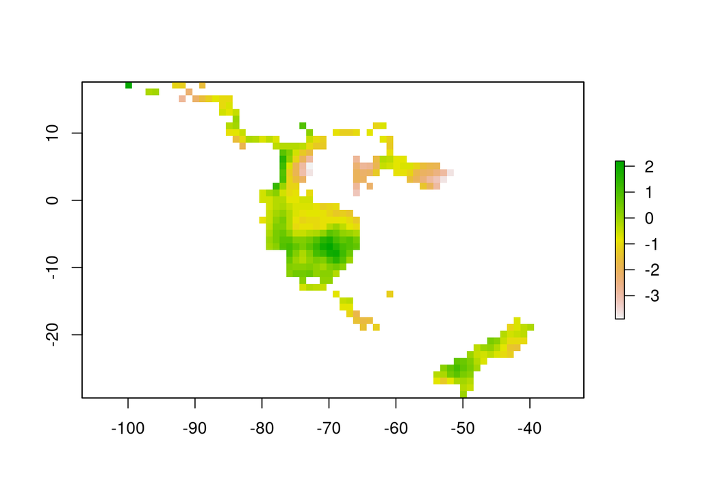

```r
dif.ols <- ols.fut.r - ols.act.r # negativo = pérdidas, positivo = ganancias
plot(dif.ols)
```

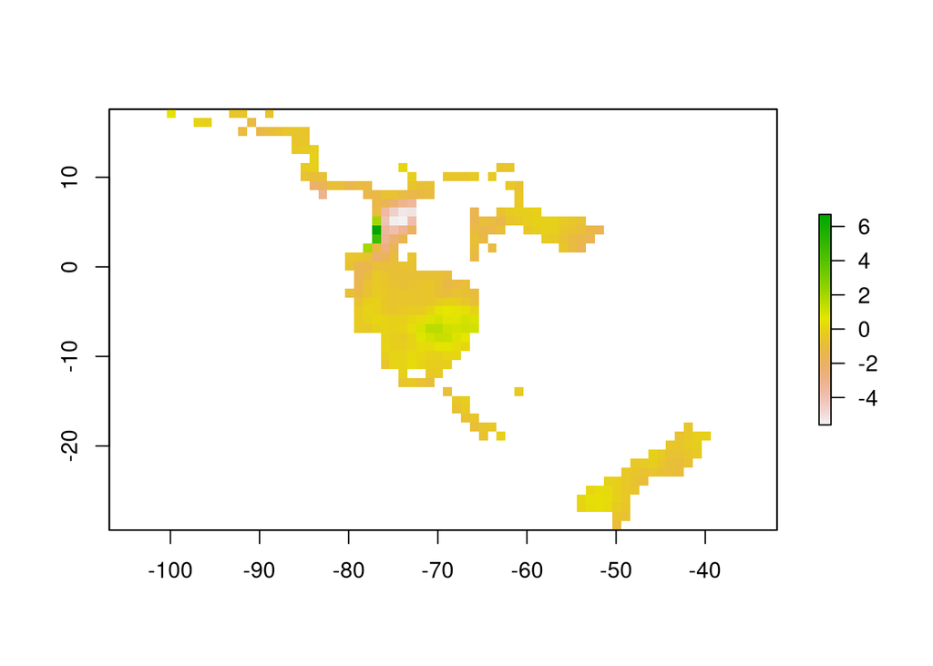

```r
dif.glm <- glm.fut.r - glm.act.r # negativo = pérdidas, positivo = ganancias
plot(dif.glm)
```

```r
perd.riq.ols <- reclassify(dif.ols, c(0, Inf, 0))
perd.riq.glm <- reclassify(dif.glm, c(0, Inf, 0))

gan.riq.ols <- reclassify(dif.ols, c(-Inf, 0, 0))
gan.riq.glm <- reclassify(dif.glm, c(-Inf, 0, 0))
```

Hacemos unos mapas bonitos

```r
library(viridis)
```

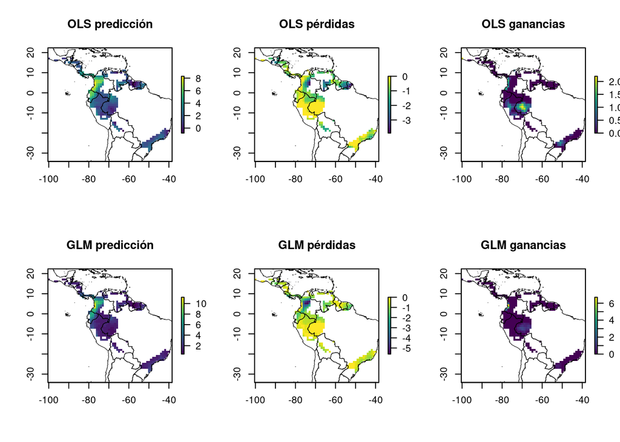

```r
par(mfrow=c(2,3))
plot(ols.act.r, main="OLS predicción", col=viridis(30))
plot(am, add=T, lwd=0.5)

plot(perd.riq.ols, main="OLS pérdidas", col=viridis(30))
plot(am, add=T, lwd=0.5)

plot(gan.riq.ols, main="OLS ganancias", col=viridis(30))
plot(am, add=T, lwd=0.5)

plot(glm.act.r, main="GLM predicción", col=viridis(30))
plot(am, add=T, lwd=0.5)

plot(perd.riq.glm, main="GLM pérdidas", col=viridis(30))
plot(am, add=T, lwd=0.5)

plot(gan.riq.glm, main="GLM ganancias", col=viridis(30))
plot(am, add=T, lwd=0.5)
```

Estos modelos son muy básicos porque solo incorporan variables bioclimáticas y la riqueza de especies está influenciada por otros factores. Aquí una literatura adicional recomendada al respecto en la que hemos trabajado con varios colegas para entender que determina la riqueza de especies en diferentes escalas y con diferentes grupos taxonómicos.

García-Rodríguez, A., Martínez, P.A., Oliveira, B.F., Velasco, J.A., Pyron, A & Costa, G.C. 2021. Amphibian speciation rates support a general role of mountains as biodiversity pumps. The American Naturalist. 198: E68-E79. https://doi.org/10.1086/715500

García-Rodriguez, A., Velasco, J.A, Villalobos, F & Parra, G. 2021. Effects of evolutionary time, speciation rates and local abiotic conditions on the origin and maintenance of amphibian montane diversity. Global Ecology and Biogeography 30: 674-684. https://doi.org/10.1111/geb.13249

Ochoa-Ochoa, L.,Mejía-Domínguez, N.R., Velasco, J.A., Dimitrov, D & Marske, K.A. 2020. Dimensions of Amphibian alpha diversity in the New World. Journal of Biogeography 47: 2293-2302.

Ochoa-Ochoa, L. M., Mejía-Domínguez, N.R.,Velasco, J.A, Marskea, K.A. & Rahbek, C. 2019. Amphibian functional diversity is related to precipitation stability in the New World. Global Ecology and Biogeography. 28: 1219-1229.

Velasco, J.A., Villalobos, F., Diniz-Filho, JAF., Algar, A.C., Flores-Villela, O., Kohler, G., Poe, S., Martínez-Meyer, E. 2018. Climatic and evolutionary factors shaping geographical gradients of species richness in Anolis lizards. Biological Journal of the Linnean Society 123: 615-627.

Eso es todo por ahora!